# Raster geodata in R; basics of functional programming in R

## Raster cropping and masking

From time to time, it is better to crop and mask the raster layers because the original data are too big. Since masking using the shape of a polygon may take a long time without first cropping the raster, the application of the `crop()` function usually precedes the application of the `mask()` function.

```r
# we found that the air temperature layers exceed the territory of Czechia
# this must apply also to our annual layer
# however, for some reasons, we need to limit our analyses only to Czechia
# so let us crop and mask the raster layer according to the borders of Czechia
airtemp_annual_masked1 <- airtemp_annual |>
  crop(republika()) |>
  mask(republika())

# note we have also a shorter way of masking raster layers if we use the same polygon for cropping and masking
airtemp_annual_masked2 <- airtemp_annual |>
  crop(republika(),
       mask = T)

# are the layers the same?
identical(airtemp_annual_masked1, airtemp_annual_masked2)
```

```
[1] TRUE
```

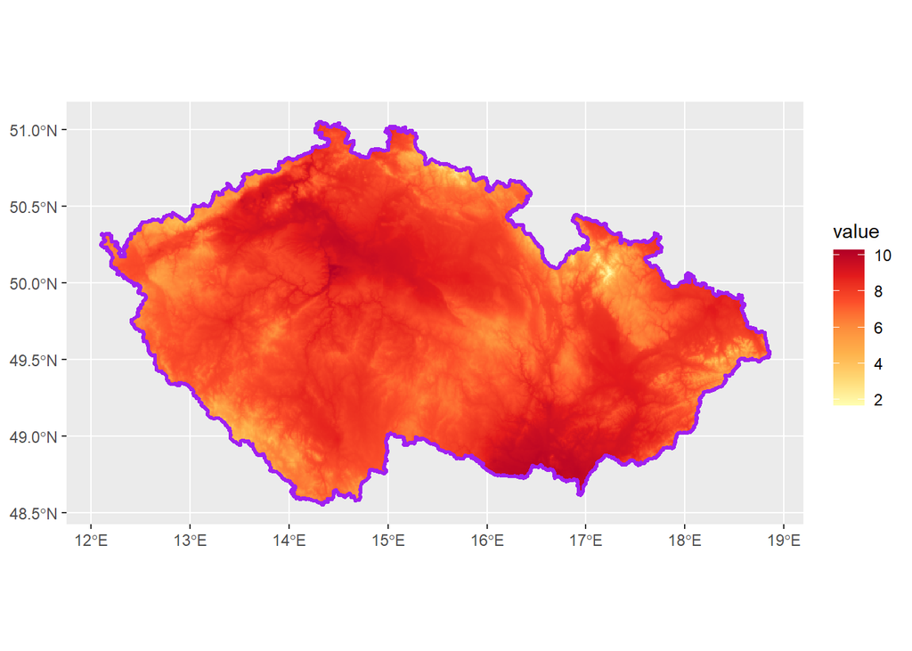

```r
ggplot() +
  geom_spatraster(data = airtemp_annual_masked1) +
  scale_fill_distiller(palette = "YlOrRd",
                       direction = 1,
                       na.value = NA) +
  geom_sf(data = republika(),
          col = "purple",
          linewidth = 1,
          fill = NA)
```

## Aspect and slope of the terrain

Often, we need to know about prevailing aspect and slope in our study area. Creation of the aspect and slope raster layers can be done through the `terrain()` function. Then, we can compute the mean aspect and slope, e.g. over administrative regions of Czechia.

```r
# we take only the czdem2 into account
czaspect <- czdem2 |>
  terrain(v = "aspect")

czslope <- czdem2 |>
  terrain(v = "slope")

# since the aspect and splope are angular variables, we need to compute the means accordingly
# one of the packages that computes angular means is the package circular
# we are going to compute the means over the administrative regions of Czechia
# we may base our computation on a new raster geodata with two layers
library(circular)

together <- c(czaspect,
              czslope)

# making use of an anonymous function and the conversion to the circular variables
results <- extract(together,
                   kraje(),
                   fun = \(x) mean(circular(x,
                                            units = "degrees"),
                                   na.rm = T),
                   ID = F) |>
  mutate(aspect = if_else(aspect < 0, 2 * pi - aspect, aspect)) # we do not want the negative values of aspect

# final modification to obtain the resulting tibble
results <- kraje() |>
  st_drop_geometry() |>
  select(NAZ_CZNUTS3) |>
  bind_cols(results) |>
  as_tibble()

results
```

```
# A tibble: 14 × 3
   NAZ_CZNUTS3          aspect     slope
   <chr>                <circular> <circular>
 1 Hlavní město Praha     6.839085 1.264434
 2 Středočeský kraj      39.569026 1.441587
 3 Jihočeský kraj        64.359247 1.789488
 4 Plzeňský kraj         73.891042 2.115896
 5 Karlovarský kraj     137.633791 2.431816
 6 Ústecký kraj          95.439190 2.506570
 7 Liberecký kraj       141.919881 2.690473
 8 Královéhradecký kraj 162.152707 2.030562
 9 Pardubický kraj       34.146049 1.738997
10 Kraj Vysočina        125.042586 1.521230
11 Jihomoravský kraj    144.341484 1.585581
12 Olomoucký kraj       151.527911 2.520859
13 Zlínský kraj         102.018276 2.684447
14 Moravskoslezský kraj  55.107543 2.579992
```

There are a bunch of other variables that can be derived by the `terrain()` function. Kindly study the help page of the function.

## Introduction to functional programming in R

Functional programming is very useful when repeating calculation with some of the changed parameters or arguments. It can be effectively used instead of for loops, and it find applications in so-called tidymodeling where many types of models are compared before the final selection of the most effective model having the data at hand. In tidyverse, functional programming is mostly performed by sing the functions of the `purrr` package. In such functional programming, mainly the `map()` function and it variants are mainly employed. The machine potential is probably the best utilized when combining functional programming with so-called parallelization (in current R provided by so-called futures and the `furrr` package).

Imagine that we want to find out what variable derived from the elevation raster layer explains the best the air temperature variability. We could select between the mean, median, standard deviation and maximum of elevation. `map()` loops over a vector or a list that can be also considered a vector. The functions that are placed inside the `map()` function and whose arguments are changed needs to be vectorized.

```r
# because map() loops over a vectors, first, create a vector of names of functions we want to apply
fns <- c("mean", "median", "sd", "max")

# pipe operator pairs well with map()
# by default, map() produces a list that can also be a column of a tibble
statistics <- tibble(fns = fns)

# often, anonymous functions are applied within map()
statistics <- statistics |>
  mutate(stats = fns |>
           map(\(x) bind_cols(kraje() |>
                                st_drop_geometry() |>
                                select(NAZ_CZNUTS3),
                              extract(czdem2,
                                      kraje(),
                                      fun = x,
                                      ID = F,
                                      na.rm = T)) |>
                 as_tibble()))

statistics
```

```
# A tibble: 4 × 2
  fns    stats
  <chr>  <list>
1 mean   <tibble [14 × 2]>
2 median <tibble [14 × 2]>
3 sd     <tibble [14 × 2]>
4 max    <tibble [14 × 2]>
```

```r
# nested list-columns can also be unnested by the function unnest()
statistics |>
  unnest(stats)
```

```
# A tibble: 56 × 3
   fns   NAZ_CZNUTS3          CZE_elv_msk
   <chr> <chr>                      <dbl>
 1 mean  Hlavní město Praha          275.
 2 mean  Středočeský kraj            355.
 3 mean  Jihočeský kraj              567.
 4 mean  Plzeňský kraj               532.
 5 mean  Karlovarský kraj            623.
 6 mean  Ústecký kraj                376.
 7 mean  Liberecký kraj              455.
 8 mean  Královéhradecký kraj        419.
 9 mean  Pardubický kraj             423.
10 mean  Kraj Vysočina               545.
# ℹ 46 more rows
```

```r
# but more importantly, they can be further processed
statistics <- statistics |>
  mutate(stats = stats |> map(\(x)
                              left_join(x,
                                        zonalstats,
                                        join_by(NAZ_CZNUTS3)))
  )

statistics |>
  unnest(stats)
```

```
# A tibble: 56 × 4
   fns   NAZ_CZNUTS3          CZE_elv_msk tavg
   <chr> <chr>                      <dbl> [°C]
 1 mean  Hlavní město Praha          275.  9.2
 2 mean  Středočeský kraj            355.  8.4
 3 mean  Jihočeský kraj              567.  7.4
 4 mean  Plzeňský kraj               532.  7.2
 5 mean  Karlovarský kraj            623.  6.6
 6 mean  Ústecký kraj                376.  8.1
 7 mean  Liberecký kraj              455.  7.3
 8 mean  Královéhradecký kraj        419.  7.3
 9 mean  Pardubický kraj             423.  7.5
10 mean  Kraj Vysočina               545.  7.3
# ℹ 46 more rows
```

```r
# we now create a new column with linear models showing the dependence of average annual air temperature of various statistical properties of the terrain in the administrative regions
statistics <- statistics |>
  mutate(models = stats |> map(\(x)
                              lm(units::drop_units(tavg) ~ CZE_elv_msk,
                                 data = x)))

# there exists a function that converts the model objetcs to a tidier format
# it is the tidy() function from the package broom
library(broom)

statistics <- statistics |>
  mutate(models2 = models |> map(tidy)) # in a simple case, there is no need to define the general variable x

statistics |>
  select(fns, models2) |>
  unnest(models2)
```

```
# A tibble: 8 × 6
  fns    term        estimate std.error statistic  p.value
  <chr>  <chr>          <dbl>     <dbl>     <dbl>    <dbl>
1 mean   (Intercept) 10.4      0.441        23.6  2.03e-11
2 mean   CZE_elv_msk -0.00619  0.000977     -6.34 3.73e- 5
3 median (Intercept)  9.93     0.510        19.5  1.91e-10
4 median CZE_elv_msk -0.00556  0.00121      -4.58 6.28e- 4
5 sd     (Intercept)  8.94     0.555        16.1  1.74e- 9
6 sd     CZE_elv_msk -0.00850  0.00354      -2.40 3.33e- 2
7 max    (Intercept)  9.56     0.455        21.0  7.80e-11
8 max    CZE_elv_msk -0.00165  0.000381     -4.33 9.70e- 4
```

```r
# but we are interested in the regression coefficients only
statistics |>
  select(fns, models2) |>
  unnest(models2) |>
  filter(term == "CZE_elv_msk")
```

```
# A tibble: 4 × 6
  fns    term        estimate std.error statistic   p.value
  <chr>  <chr>          <dbl>     <dbl>     <dbl>     <dbl>
1 mean   CZE_elv_msk -0.00619  0.000977     -6.34 0.0000373
2 median CZE_elv_msk -0.00556  0.00121      -4.58 0.000628
3 sd     CZE_elv_msk -0.00850  0.00354      -2.40 0.0333
4 max    CZE_elv_msk -0.00165  0.000381     -4.33 0.000970
```

```r
# based on the p-value, it seems that from all the statistics, the mean elevation is the best for estimating average annual air temperature in the territory of Czechia
statistics |>
  select(fns, models2) |>
  unnest(models2) |>
  filter(term == "CZE_elv_msk") |>
  slice_min(order_by = p.value,
            n = 1)
```

```
# A tibble: 1 × 6
  fns   term        estimate std.error statistic   p.value
  <chr> <chr>          <dbl>     <dbl>     <dbl>     <dbl>
1 mean  CZE_elv_msk -0.00619  0.000977     -6.34 0.0000373
```

```r
# everything may be computed in a faster way if we perform parallelization
library(furrr)

# this works on Windows
plan(multisession,
     workers = availableCores())

# since terra utilizes external functions written in C++, raster layers need to be wrapped first, and then unwrapped in another functions applied by the slaves
czdem2_wrapped <- wrap(czdem2)

# we also rather create a new sf object with administrative regions so that this vector layer is not downloaded several times
regions <- kraje()

tibble(fns = fns) |>
  mutate(stats = fns |>
           future_map(\(x) bind_cols(regions |>
                                       st_drop_geometry() |>
                                       select(NAZ_CZNUTS3),
                                     terra::extract(unwrap(czdem2_wrapped), # there are often coflicts regarding different extract() functions from different packages
                                                    regions,
                                                    fun = x,
                                                    ID = F,
                                                    na.rm = T)) |>
                        as_tibble() |>
                        left_join(zonalstats,
                                  join_by(NAZ_CZNUTS3)),
                      .options = furrr_options(seed = NULL, # we do not want to generate pseudorandom numbers
                                               packages = c("tidyverse", # slaves need to know the packages from which the applied functions come
                                                            "terra",
                                                            "RCzechia"), # sf is loaded automatically
                                               globals = c("zonalstats", # slaves need to know the variables from the Global Environment
                                                           "czdem2_wrapped",
                                                           "regions"))),
         models = stats |>
           future_map(\(x)
                      lm(units::drop_units(tavg) ~ CZE_elv_msk,
                         data = x) |>
                        tidy(),
                      .options = furrr_options(seed = NULL,
                                               packages = c("tidyverse",
                                                            "broom")))) |>
  select(fns, models) |>
  unnest(models) |>
  filter(term == "CZE_elv_msk") |>
  slice_min(order_by = p.value,
            n = 1)
```

```
# A tibble: 1 × 6
  fns   term        estimate std.error statistic   p.value
  <chr> <chr>          <dbl>     <dbl>     <dbl>     <dbl>
1 mean  CZE_elv_msk -0.00619  0.000977     -6.34 0.0000373
```

```r
# and we return to the normal mode
plan(sequential)

# we can even measure the time taken by the computation, and find which way is truly faster
# first, try sequential computation
tictoc::tic(); tibble(fns = fns) |>
  mutate(stats = fns |>
           map(\(x) bind_cols(regions |>
                                st_drop_geometry() |>
                                select(NAZ_CZNUTS3),
                              terra::extract(czdem2,
                                             regions,
                                             fun = x,
                                             ID = F,
                                             na.rm = T)) |>
                 as_tibble() |>
                 left_join(zonalstats,
                           join_by(NAZ_CZNUTS3))),
         models = stats |>
           map(\(x)
               lm(units::drop_units(tavg) ~ CZE_elv_msk,
                  data = x) |>
                 tidy())) |>
  select(fns, models) |>
  unnest(models) |>
  filter(term == "CZE_elv_msk") |>
  slice_min(order_by = p.value,
            n = 1); tictoc::toc()
```

```
# A tibble: 1 × 6
  fns   term        estimate std.error statistic   p.value
  <chr> <chr>          <dbl>     <dbl>     <dbl>     <dbl>
1 mean  CZE_elv_msk -0.00619  0.000977     -6.34 0.0000373
```

```
1.79 sec elapsed
```

```r
# second, try parallel computation
plan(multisession,
     workers = availableCores())

tictoc::tic(); tibble(fns = fns) |>
  mutate(stats = fns |>
           future_map(\(x) bind_cols(regions |>
                                       st_drop_geometry() |>
                                       select(NAZ_CZNUTS3),
                                     terra::extract(unwrap(czdem2_wrapped),
                                                    regions,
                                                    fun = x,
                                                    ID = F,
                                                    na.rm = T)) |>
                        as_tibble() |>
                        left_join(zonalstats,
                                  join_by(NAZ_CZNUTS3)),
                      .options = furrr_options(seed = NULL,
                                               packages = c("tidyverse",
                                                            "terra",
                                                            "RCzechia"),
                                               globals = c("zonalstats",
                                                           "czdem2_wrapped",
                                                           "regions"))),
         models = stats |>
           future_map(\(x)
                      lm(units::drop_units(tavg) ~ CZE_elv_msk,
                         data = x) |>
                        tidy(),
                      .options = furrr_options(seed = NULL,
                                               packages = c("tidyverse",
                                                            "broom")))) |>
  select(fns, models) |>
  unnest(models) |>
  filter(term == "CZE_elv_msk") |>
  slice_min(order_by = p.value,
            n = 1); tictoc::toc()
```

```
# A tibble: 1 × 6
  fns   term        estimate std.error statistic   p.value
  <chr> <chr>          <dbl>     <dbl>     <dbl>     <dbl>
1 mean  CZE_elv_msk -0.00619  0.000977     -6.34 0.0000373
```

```
7.33 sec elapsed
```

```r
plan(sequential)

# we can see that it depends on the situation, and we need to have own experience
# perhaps, with rising amount of data, the parallel approach would win
# also, it highly depends on the machine we have at hand (RAM, number of logical cores, etc.)
```

`map()` has many variants according to what they return. However, what follows after the underscore in the names of those functions very well suggests what is returned. For instance, `map_lgl()` returns a logical vector. It must be ensured that the result of each loop satisfies the condition for applying such functions. There is also a difference between `map()` and `walk()`. As a rule of thumb, `walk()` is applied where something goes outside R. This includes saving files to a disc. More about functional programming can be found in a chapter of Wickham et al. (2023). More about programming in R in general can be found in other books as well Wickham and Bryan (2023).

## References

Hernangómez, D.: Using the tidyverse with terra objects: The tidyterrapackage, Journal of Open Source Software, 8, 5751, https://doi.org/10.21105/joss.05751, 2023.

Hijmans, R. J.: [Terra: Spatial data analysis](https://CRAN.R-project.org/package=terra), 2024.

Hijmans, R. J., Barbosa, M., Gosh, A., and Mandel, A.: [Geodata: Download geographic data](https://CRAN.R-project.org/package=geodata), 2023.

Lacko, J.: RCzechia: Spatial objects of the czech republic, Journal of Open Source Software, 8, 5082, https://doi.org/10.21105/joss.05082, 2023.

Pebesma, E. J. and Bivand, R.: Spatial Data Science: With Applications in R, CRC Press, Boca Raton, 2023.

Wickham, H.: Advanced R, 2nd ed., CRC Press, Boca Raton, 2019.

Wickham, H. and Bryan, J.: R packages: Organize, test, document, and share your code, 2nd ed., O’Reilly, Beijing, 2023.

Wickham, H., Çetinkaya-Rundel, M., and Grolemund, G.: R for Data Science: Import, Tidy, Transform, Visualize, and Model Data, 2nd ed., O’Reilly Media, Inc, Sebastopol, CA, 2023.

## Footnotes

[^1]: However, original functions brought by `terra` might be much faster sometimes.